# 2. R 따라해보기

## R 기본원리 4가지

R은 기본적으로 프로그래밍 언어입니다.

하지만 C, Basic, Fortran 등과 달리 컴파일(compile)언어가 아닌 인터프리터(interpreter) 언어입니다.

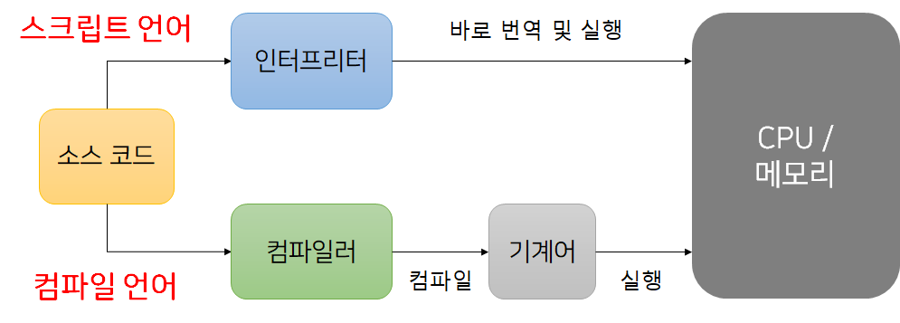

대화형 프로그래밍이 가능하므로 다른 언어에 비해 상대적으로 쉽게 배우고 사용하실 수 있습니다.

그러면 R 언어에서 중요한 4가지를 살펴보겠습니다.

```
1. 화살표를 이용하여 원하는 이름으로 객체를 명명할 수 있다.

2. 소괄호()는 함수이고, R 프로그램은 함수 놀이다.

3. 기본 함수 외 함수는 package를 설치하면 이용할 수 있다.

4. 중괄호[]는 index를 의미하고 원하는 위치에 있는 자료를 선택할 수 있다.
```

### 1. 내가 원하는 이름으로 모든 객체를 저장하여 사용

`->`, `->`, `=`를 사용하여 원하는 이름에 저장할 수 있습니다.

```r
a <- 5
a
```

```
## [1] 5
```

```r
5 -> b
b
```

```
## [1] 5
```

```r
c = 5
c
```

```
## [1] 5
```

```r
a+b+c
```

```
## [1] 15
```

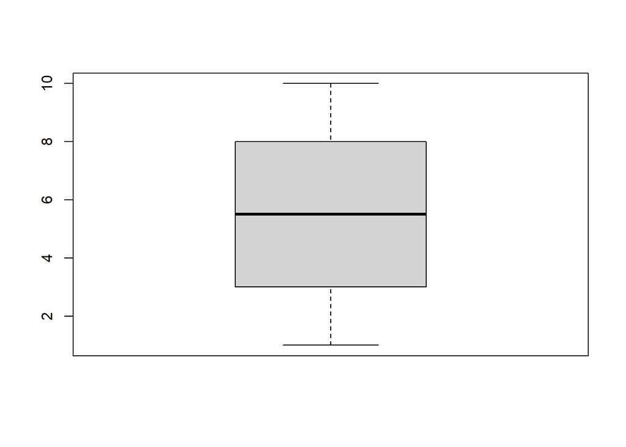

```r
d <- boxplot(1:10)
```

```r
d
```

```
## $stats
##      [,1]
## [1,]  1.0
## [2,]  3.0
## [3,]  5.5
## [4,]  8.0
## [5,] 10.0
## attr(,"class")
##         1
## "integer"
##
## $n
## [1] 10
##
## $conf
##          [,1]
## [1,] 3.001801
## [2,] 7.998199
##
## $out
## numeric(0)
##
## $group
## numeric(0)
##
## $names
## [1] "1"
```

```r
f <- lm(dist~speed, data=cars)
f
```

```
##
## Call:
## lm(formula = dist ~ speed, data = cars)
##
## Coefficients:
## (Intercept)        speed
##     -17.579        3.932
```

### 2. 소괄호는 함수를 의미합니다.

함수는 다른 연구자들에 의해 정의된 프로그램으로 함수의 사용방법만 알면 쉽게 이용하실 수 있습니다.

예를 들어 sample()는 내가 원하는 범위의 수를 랜덤하게 선택하는 함수 입니다.

```r
sample(1:45,6)
```

```
## [1] 22 35 20 34 16 45
```

위 함수가 흔히 알고있는 `로또 번호 생성기` 입니다.

함수를 실행하실때마다 다른 결과가 나옵니다.

처음 함수를 이용하시는 분들은 #(sharp sign) 으로 주석을 달아주시면 향후 쉽게 코드를 이해하실 수 있습니다.

```r
sample(1:45,6)  #1부터 45까지 숫자 중 임의로 6개 비복원 선택
```

```
## [1] 13 31 26 18 20 15
```

```r
args(sample)
```

```
## function (x, size, replace = FALSE, prob = NULL)
## NULL
```

그리고 args()는 함수의 사용법을 간략히 보여주며 함수 앞에 ?를 붙히면 도움말을 확인하실 수 있습니다.

R 언어는 **얼마나 많은 함수를 원하는 목적에 활용할 수 있는가**가 전문가와 비전문가를 구분하는 기준이라고 생각합니다.

### 3. 기본 함수 외 함수는 package를 설치하면 이용할 수 있습니다.

뒤에 배우겠지만, package는 함수의 주머니로 볼 수 있습니다.

기본 R 프로그램의 용량은 크지 않지만 다양한 package를 설치하면 용량이 커지고 그 만큼 다양한 분석에 사용하실 수 있습니다.

```r
# World map
map('world',
    col="#f2f2f2", fill=TRUE, bg="white", lwd=0.05,
    mar=rep(0,4),border=0, ylim=c(-80,80)
)
```

위의 코드를 그냥 실행시키면 오류가 발생하여 실행되지 않지만.

install.packages()를 이용하여 함수를 설치한 후 library()로 불러오면 패키지 않에 있는 함수를 이용하실 수 있습니다.

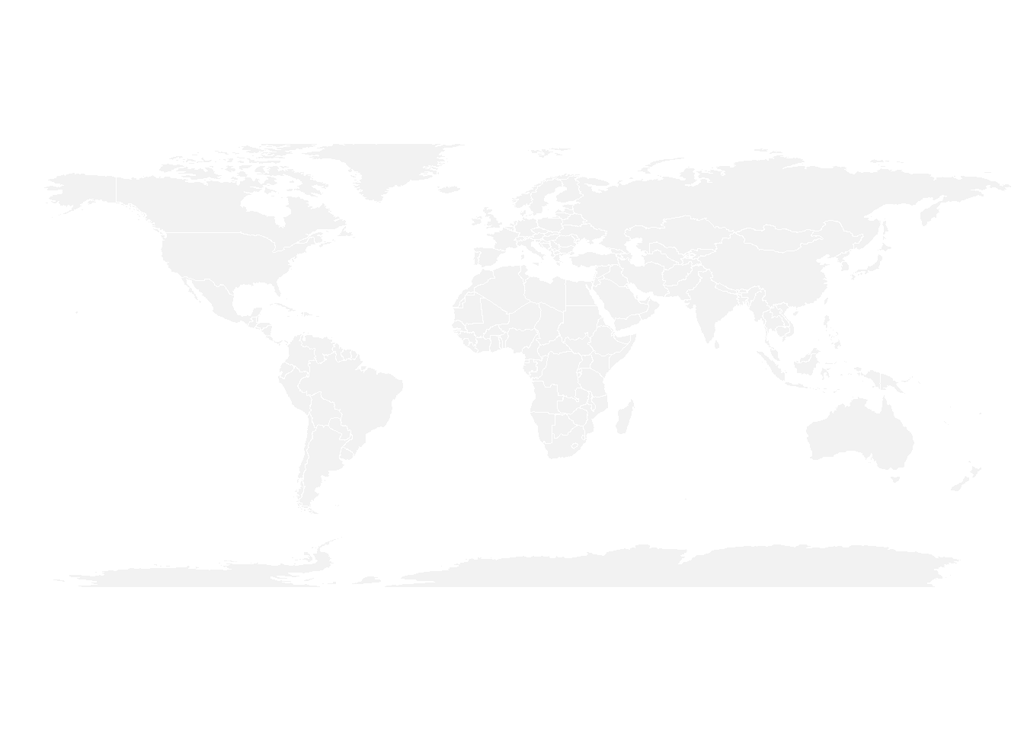

```r
if(!require(maps)) install.packages("maps")
library(maps)
# World map
map('world',
    col="#f2f2f2", fill=TRUE, bg="white", lwd=0.05,
    mar=rep(0,4),border=0, ylim=c(-80,80)
)
```

### 4. 원하는 행과 열을 선택하고자 하면 [] 중괄호는 이용하세요.

```r
head(iris)
```

```
##   Sepal.Length Sepal.Width Petal.Length Petal.Width Species
## 1          5.1         3.5          1.4         0.2  setosa
## 2          4.9         3.0          1.4         0.2  setosa
## 3          4.7         3.2          1.3         0.2  setosa
## 4          4.6         3.1          1.5         0.2  setosa
## 5          5.0         3.6          1.4         0.2  setosa
## 6          5.4         3.9          1.7         0.4  setosa
```

iris 꽃 품종에 대한 데이터 입니다.

R를 이용해서 간략히 살펴보면

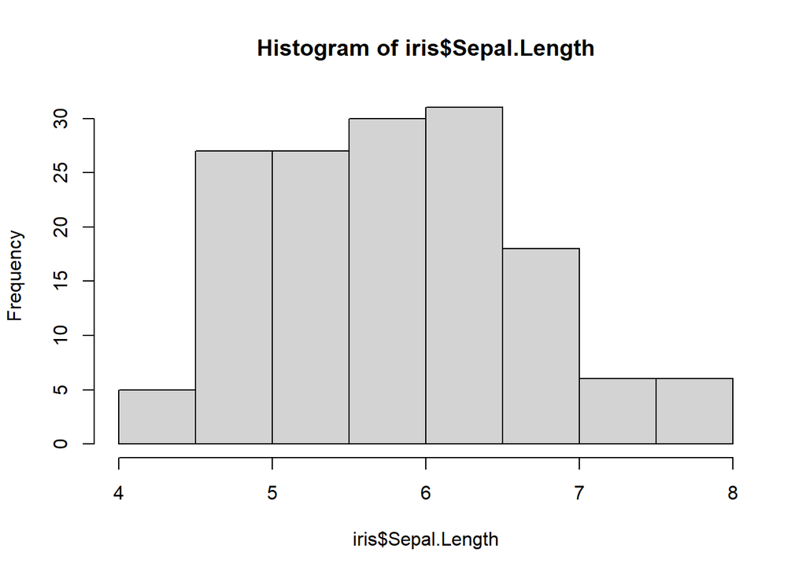

```r
hist(iris$Sepal.Length)   # 히스토그램 그리기
```

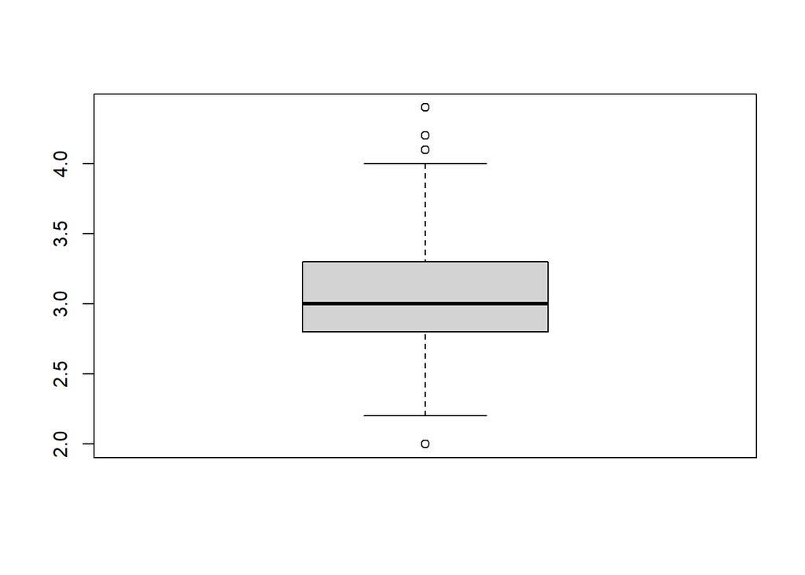

```r
boxplot(iris$Sepal.Width)   # 상자그림 그리기
```

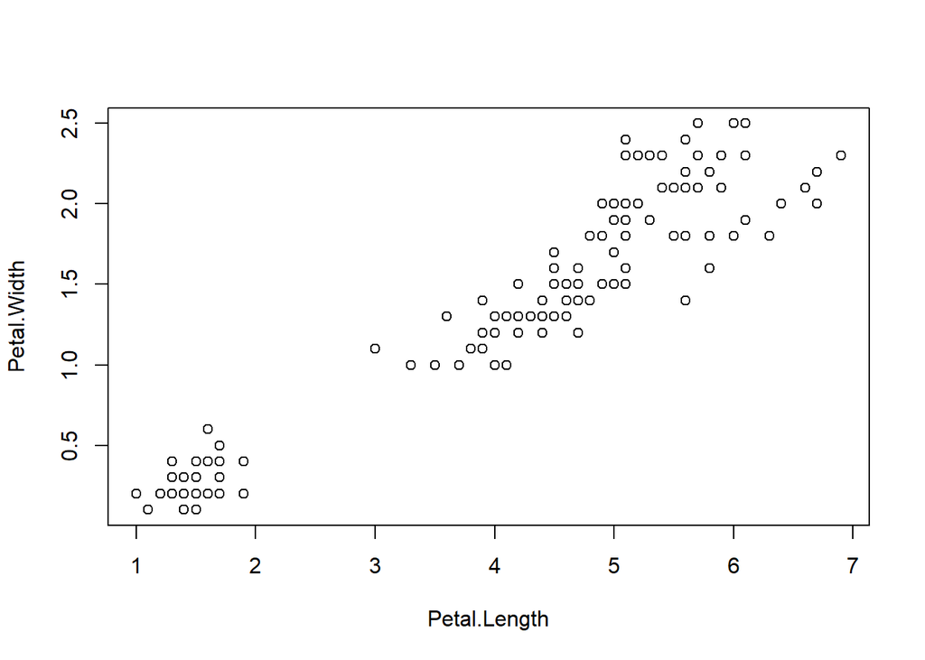

```r
plot(Petal.Width ~ Petal.Length, data=iris) # 산점도 그리기
```

```r
setosa <- iris[iris$Species=="setosa" ,] #iris품종이 setosa만 선택하기

head(iris[,c("Sepal.Length","Species")]) ## 원하는 열만 선택
```

```
##   Sepal.Length Species
## 1          5.1  setosa
## 2          4.9  setosa
## 3          4.7  setosa
## 4          4.6  setosa
## 5          5.0  setosa
## 6          5.4  setosa
```

```r
head(iris$Species) # data.frame의 경우 $를 이용하여 원하는 열 선택 가능
```

```
## [1] setosa setosa setosa setosa setosa setosa
## Levels: setosa versicolor virginica
```

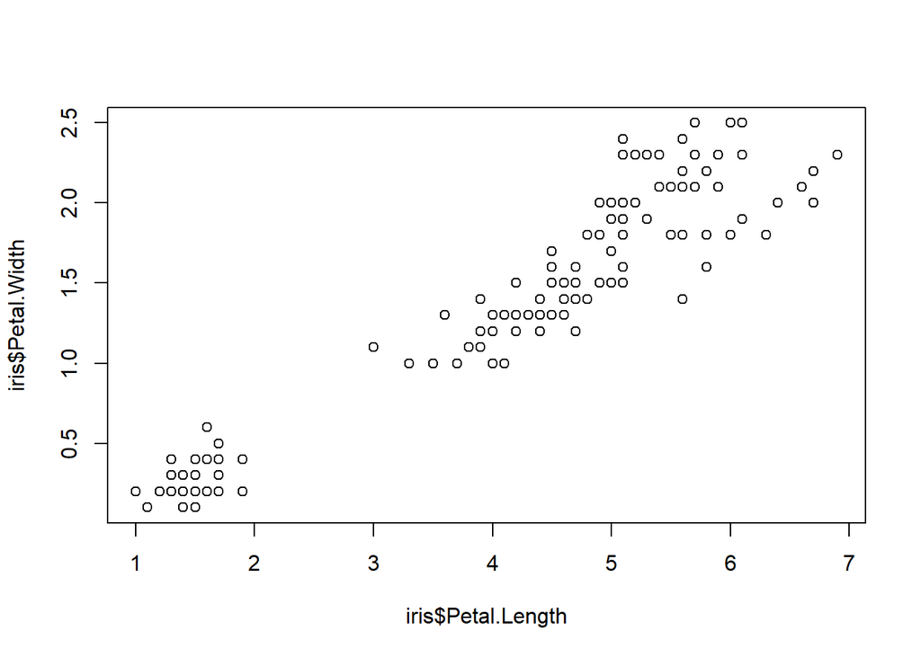

```r
plot(iris$Petal.Length, iris$Petal.Width)
```

R 연산자와 이용하면 도움이 많이 됩니다

## R 계산기로 사용하기

### 1. 연산자를 이용한 계산

R은 프로그래밍 언어로써의 통계계산 외에도 다양한 계산이 용이합니다.

그러면 R를 계산기로 사용하는 방법을 배워보겠습니다.

R에서 사용하는 연산자는

```
+(덧셈), -(뺄셈), *(곱셈), /(나눗셈), %/%(정수나눗셈), %%(나머지), ^(제곱)
```

우선순위는 표준적인 연산의 우선순위를 따릅니다.

괄호 안쪽의 수식, 지수 및 근호, 곱하기와 나누기, 더하기와 빼기 순입니다.

```r
 3/(2-1)     # 괄호안의 숫자는 항상 우선순위가 높음
```

```
## [1] 3
```

```r
-3^2         # 거듭제곱이 먼저 계산
```

```
## [1] -9
```

```r
sqrt(3+5)*2  # 루트의 계산은 sqrt()함수를 사용하며 우선순위가 높음
```

```
## [1] 5.656854
```

```r
12 + 34 - 56 * 78 / 90   # 곱하기, 나누기의 우선순위는 더하기 빼기보다 높음
```

```
## [1] -2.533333
```

```r
pi  # 파이(주기율)
```

```
## [1] 3.141593
```

```r
log(100, base=10)   # 밑이 10인 로그
```

```
## [1] 2
```

```r
log(100)            # 밑이 e인 로그
```

```
## [1] 4.60517
```

```r
exp(2)            # 지수함수
```

```
## [1] 7.389056
```

```r
sin(1/4*pi)         # 삼각함수
```

```
## [1] 0.7071068
```

```r
1/(sqrt(2))
```

```
## [1] 0.7071068
```

### 2. 함수를 이용한 복잡한 계산

복잡한 미분과 적분도 할 수 있습니다.

```r
f <- expression(a*x^5+b*x^2+c) # 미분할 함수 f를 정의

D(f, "x") # 함수 f를 X로 미분
```

```
## a * (5 * x^4) + b * (2 * x)
```

```r
f <- function(x) x # 적분할 함수 f를 정의

integrate(f, 0, 1) # 0과 1의 범위에서 적분 실행
```

```
## 0.5 with absolute error < 5.6e-15
```

### 3. 계산기 문제 풀이 예

```r
1 + 2 - 3
```

```
## [1] 0
```

```r
1/2
```

```
## [1] 0.5
```

```r
2^5
```

```
## [1] 32
```

```r
(1+2-3*4)/5^6 * 7000
```

```
## [1] -4.032
```

```r
5==5 # 논리식(등호)
```

```
## [1] TRUE
```

```r
5 != 5 # 논리식(등호 부정)
```

```
## [1] FALSE
```

```r
5 >=2 #논리식(부등호)
```

```
## [1] TRUE
```

```r
5 <=2 #논리식(부등호)
```

```
## [1] FALSE
```

```r
5 > 2 #부등호
```

```
## [1] TRUE
```

$a = ln(1503)$

$b = {{1} \over {\sqrt(1.13)}}$

$c = 3162615 / 37$의 몫과 나머지

$d = (1- e^{- \lambda x}), \lambda=3, x=5$

위의 문제를 R를 이용해서 풀이를 하면

```r
a = log(1503)
a
```

```
## [1] 7.315218
```

```r
b= 1 / sqrt(1.13)
b
```

```
## [1] 0.9407209
```

```r
c1 = 3162615 %/% 37
c2 = 3162615 %% 37
c1
```

```
## [1] 85476
```

```r
c2
```

```
## [1] 3
```

```r
lambda = 3
x=5

d = 1 - exp(-1 * lambda * x)
d
```

```
## [1] 0.9999997
```

으로 계산할 수 있습니다.

Q1. 100^(1/2)와 100^1/2의 결과는 같을까요? 다르다면 그 이유는?

Q2. 2의 세제곱근을 R로 구하면?

Q3. 123/0은 R에서 어떻게 계산할까요?

Q4. 0/0은 R에서 어떻게 계산할까요?

Q5. -123/0은 R에서 어떻게 계산할까요?

### 4. 문제

Q1.
$$9 + 2 \times 3 + 1$$

Q2.
$${{(7^2 -34 + 5 \times 2)^3} \over {8}} + 7 \times 23$$

Q3.
$${{2 \times (3+7)/2 + 2} \over {4}}$$

Q4.
$$\pi \times 2 \sqrt{2}$$

Q5.
$$log_2 (2^5)$$

Q6. x에 3을 대입 후 $sin(x)^2 + cos(x)^2$을 구하세요.

Q7. 우리나라 초고압 송전전력은 345[kW]이다. 선로 길이가 200[km]인 경우 1회선로당 가능한 사용전압은 몇 [kV]인지 실험식을 이용하여 구하시오.

실험식 : $사용전압 = 5.5 \sqrt{0.6 \times 송전거리 + {{송전전력} \over {100}}}$